# Clase 0. Introducción a las Series de Tiempo

Series de Tiempo | Semestre 2027-I | FC-UNAM

Benjamin Oliva

agosto 2026

## ¿Qué aprenderemos hoy?

Esta sesión introductoria presenta las herramientas básicas para trabajar con series de tiempo en R: importación de datos, declaración de objetos `ts` y visualización de series económicas mexicanas.

Al terminar esta clase deberías poder:

1. Importar datos desde un archivo `.xlsx` con `readxl`
2. Declarar una serie de tiempo con `ts()` especificando inicio y frecuencia
3. Construir gráficas comparativas con el sistema base de R
4. Aplicar transformaciones básicas: índice base y diferencias logarítmicas

**Datos:** `Base_1_TimeSeries.xlsx` **Fuentes:** INEGI, Banxico, Bolsa Mexicana de Valores

### Dependencies and Setup

```r
#install.packages("readxl")
library(readxl)
```

### Carga de datos

Los datos incluidos en `Base_1_TimeSeries.xlsx` son:

| Variable | Descripción |
| --- | --- |
| `IGAE_2018` | Indicador Global de la Actividad Económica, base 2018 |
| `IGAE_PRIM_2018` | IGAE, Actividades Primarias, base 2018 |
| `ICC` | Índice de Confianza del Consumidor (puntos) |
| `ICC_LAG` | ICC comparado con la situación económica hace 12 meses (puntos) |
| `IPC_BMV` | Índice de Precios y Cotizaciones BMV (base oct-1978 = 0.78) |
| `TDC` | Tipo de Cambio peso/dólar interbancario (pesos) |

```r
Base_1 <- read_excel("Base_1_TimeSeries.xlsx", sheet = "Hoja 1", col_names = TRUE)

head(Base_1)
```

```
## # A tibble: 6 × 7
##   Periodo IGAE_2018 IGAE_PRIM_2018   ICC ICC_LAG IPC_BMV   TDC
##   <chr>       <dbl>          <dbl> <dbl>   <dbl>   <dbl> <dbl>
## 1 2002/01      70.6           76.1  36.9    43.4   6928.  9.16
## 2 2002/02      69.2           66.2  37.6    43.5   6734.  9.10
## 3 2002/03      72.6           65.0  39.8    44.7   7362.  9.07
## 4 2002/04      73.0           65.9  39.8    44.6   7481.  9.16
## 5 2002/05      74.2           76.0  41.6    46.6   7032.  9.52
## 6 2002/06      73.7           79.7  41.5    46.7   6461.  9.77
```

```r
str(Base_1)
```

```
## tibble [281 × 7] (S3: tbl_df/tbl/data.frame)
##  $ Periodo       : chr [1:281] "2002/01" "2002/02" "2002/03" "2002/04" ...
##  $ IGAE_2018     : num [1:281] 70.6 69.2 72.6 73 74.2 ...
##  $ IGAE_PRIM_2018: num [1:281] 76.1 66.2 65 65.9 76 ...
##  $ ICC           : num [1:281] 36.9 37.6 39.8 39.8 41.6 ...
##  $ ICC_LAG       : num [1:281] 43.4 43.5 44.7 44.6 46.6 ...
##  $ IPC_BMV       : num [1:281] 6928 6734 7362 7481 7032 ...
##  $ TDC           : num [1:281] 9.16 9.1 9.07 9.16 9.52 ...
```

### Declaración de series de tiempo

```r
IGAE_2018      <- ts(Base_1$IGAE_2018,      start = 2002, freq = 12)
IGAE_PRIM_2018 <- ts(Base_1$IGAE_PRIM_2018, start = 2002, freq = 12)
ICC            <- ts(Base_1$ICC,            start = 2002, freq = 12)
ICC_LAG        <- ts(Base_1$ICC_LAG,        start = 2002, freq = 12)
IPC_BMV        <- ts(Base_1$IPC_BMV,        start = 2002, freq = 12)
TDC            <- ts(Base_1$TDC,            start = 2002, freq = 12)
```

### Gráfica 1 — IGAE total vs actividades primarias

```r
summary(IGAE_2018,      digits = 4)
```

```
##    Min. 1st Qu.  Median    Mean 3rd Qu.    Max.
##   69.19   81.80   90.21   89.56   98.22  108.50
```

```r
summary(IGAE_PRIM_2018, digits = 4)
```

```
##    Min. 1st Qu.  Median    Mean 3rd Qu.    Max.
##   57.82   75.57   86.91   89.02   98.65  145.40
```

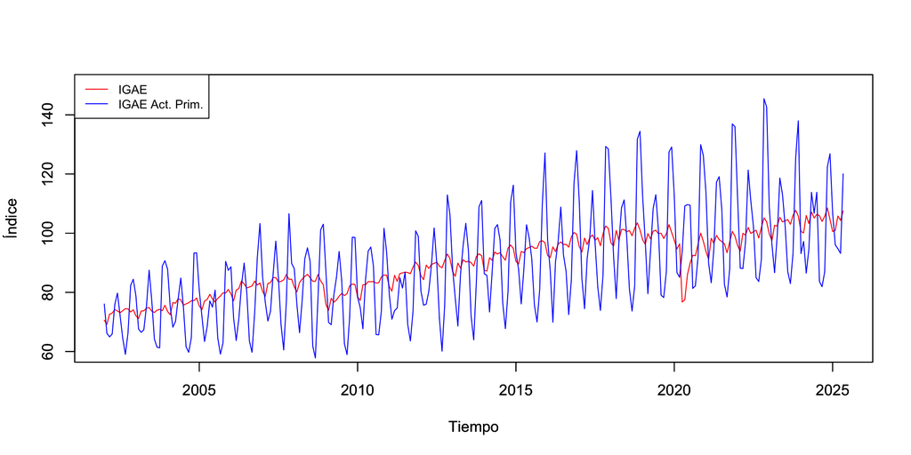

```r
plot(IGAE_2018, type = "l", lwd = 1, col = "red",
     ylab = "Índice", xlab = "Tiempo", ylim = c(60, 150))
par(new = TRUE)
plot(IGAE_PRIM_2018, type = "l", lwd = 1, col = "blue",
     ylab = "Índice", xlab = "Tiempo", ylim = c(60, 150))
legend("topleft", c("IGAE", "IGAE Act. Prim."),
       cex = 0.8, lty = 1, col = c("red", "blue"))
```

```r
par(new = FALSE)
```

### Gráfica 2 — Índice de Confianza del Consumidor

```r
summary(ICC,     digits = 4)
```

```
##    Min. 1st Qu.  Median    Mean 3rd Qu.    Max.
##   28.67   37.42   39.84   40.21   43.32   48.90
```

```r
summary(ICC_LAG, digits = 4)
```

```
##    Min. 1st Qu.  Median    Mean 3rd Qu.    Max.
##   34.06   43.69   45.29   45.49   47.75   52.92
```

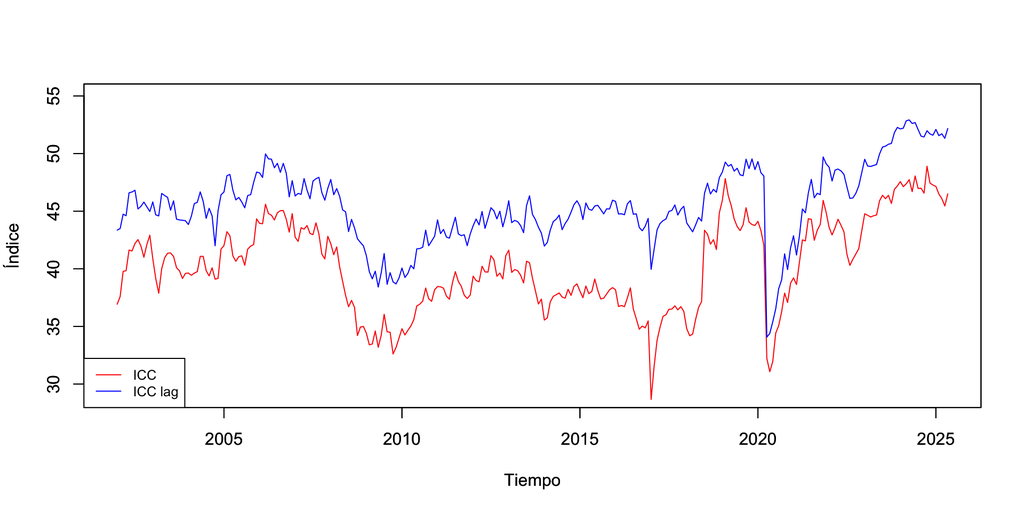

```r
plot(ICC, type = "l", lwd = 1, col = "red",
     ylab = "Índice", xlab = "Tiempo", ylim = c(29, 55))
par(new = TRUE)
plot(ICC_LAG, type = "l", lwd = 1, col = "blue",
     ylab = "Índice", xlab = "Tiempo", ylim = c(29, 55))
legend("bottomleft", c("ICC", "ICC lag"),
       cex = 0.8, lty = 1, col = c("red", "blue"))
```

```r
par(new = FALSE)
```

### Gráfica 3 — IPC BMV y Tipo de Cambio (niveles)

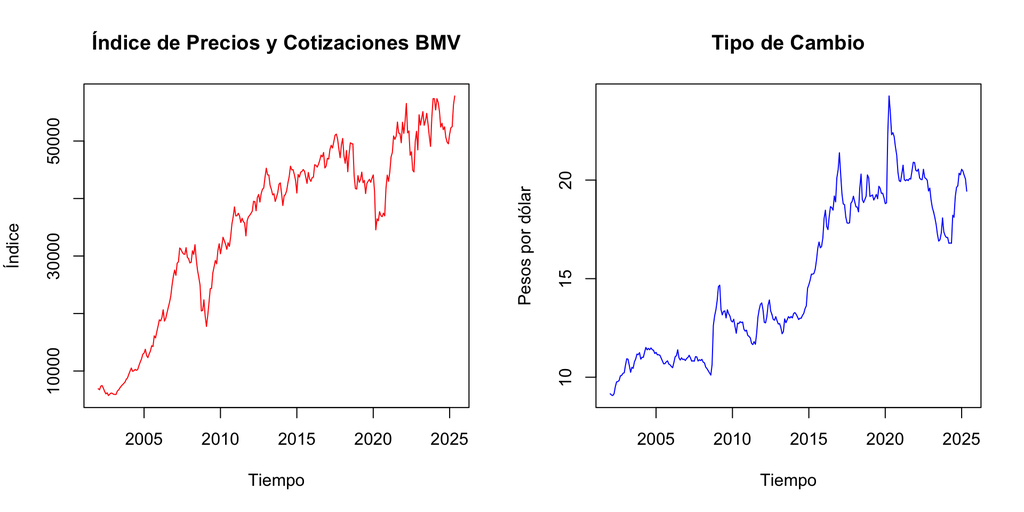

```r
par(mfrow = c(1, 2))
plot(IPC_BMV, type = "l", lwd = 1, col = "red",
     ylab = "Índice", xlab = "Tiempo",
     main = "Índice de Precios y Cotizaciones BMV")
plot(TDC, type = "l", lwd = 1, col = "blue",
     ylab = "Pesos por dólar", xlab = "Tiempo",
     main = "Tipo de Cambio")
```

```r
par(mfrow = c(1, 1))
```

### Gráfica 4 — IPC BMV y TDC reindexados (base = enero 2002)

Transformamos ambas series a un número índice con base en el primer mes de la muestra para hacerlas comparables en la misma escala.

```r
IPC_BMV_I <- 100 * IPC_BMV / IPC_BMV[1]
TDC_I     <- 100 * TDC     / TDC[1]

summary(IPC_BMV_I, digits = 4)
```

```
##    Min. 1st Qu.  Median    Mean 3rd Qu.    Max.
##   82.69  381.80  587.50  513.00  676.40  834.90
```

```r
summary(TDC_I,     digits = 4)
```

```
##    Min. 1st Qu.  Median    Mean 3rd Qu.    Max.
##   99.01  122.80  145.90  164.00  207.20  264.90
```

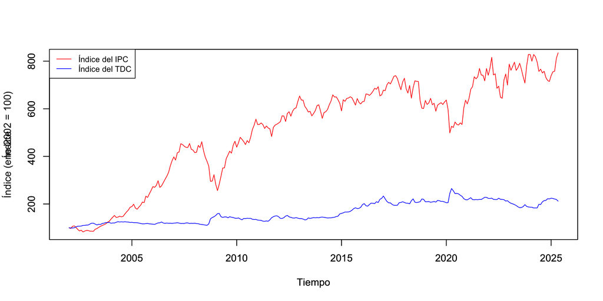

```r
plot(IPC_BMV_I, type = "l", lwd = 1, col = "red",
     ylab = "Índice (ene-2002 = 100)", xlab = "Tiempo", ylim = c(80, 820))
par(new = TRUE)
plot(TDC_I, type = "l", lwd = 1, col = "blue",
     ylab = "Índice", xlab = "Tiempo", ylim = c(80, 820))
legend("topleft", c("Índice del IPC", "Índice del TDC"),
       cex = 0.8, lty = 1, col = c("red", "blue"))
```

```r
par(new = FALSE)
```

### Gráfica 5 — Diferencias logarítmicas (variaciones porcentuales)

La diferencia logarítmica $\Delta \ln X_t = \ln X_t - \ln X_{t-1}$ aproxima la tasa de variación porcentual de la serie.

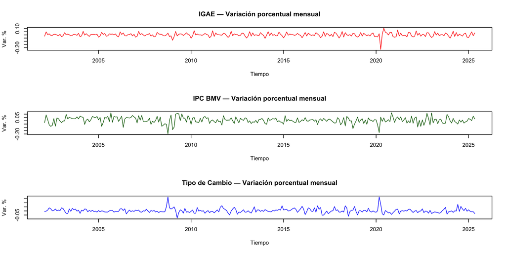

```r
par(mfrow = c(3, 1))
plot(diff(log(IGAE_2018), lag = 1), type = "l", lwd = 1, col = "red",
     ylab = "Var. %", xlab = "Tiempo",
     main = "IGAE — Variación porcentual mensual")
plot(diff(log(IPC_BMV), lag = 1), type = "l", lwd = 1, col = "darkgreen",
     ylab = "Var. %", xlab = "Tiempo",
     main = "IPC BMV — Variación porcentual mensual")
plot(diff(log(TDC), lag = 1), type = "l", lwd = 1, col = "blue",
     ylab = "Var. %", xlab = "Tiempo",
     main = "Tipo de Cambio — Variación porcentual mensual")
```

```r
par(mfrow = c(1, 1))
```

### Guardado del objeto de datos

```r
save(Base_1, file = "Base_1.RData")
```

## Ejercicios

1. ¿En qué mes y año alcanzó el IPC BMV su valor máximo? Usa `which.max()`.
2. Calcula la variación porcentual promedio anual del Tipo de Cambio en toda la muestra. ¿En qué periodo fue más volátil?
3. Aplica `diff(..., lag = 12)` a `IGAE_2018` para obtener la variación anual en lugar de mensual. ¿Cómo cambia la gráfica?